# Different data formats

Di Cook, Heike Hofmann  
1/17/2014

### NETCDF

- Scientific binary format
- Self-describing, machine independent
- Typically used for large climate data sets

[Source](http://www.unidata.ucar.edu/software/netcdf/)

### NETCDF and R

```r
library("ncdf")
fo<-open.ncdf("../data/sweden.temp.01-10.nc")
sweden.temp <- get.var.ncdf(fo, "tasol")
dim(sweden.temp)
```

```
[1]   40   66 3287
```

### NETCDF and R

```r
lon <- get.var.ncdf(fo, "lon")
lat <- get.var.ncdf(fo, "lat")
time <- get.var.ncdf(fo, "time")
oneloc <- data.frame(time,
    temp=sweden.temp[6,1,])
```

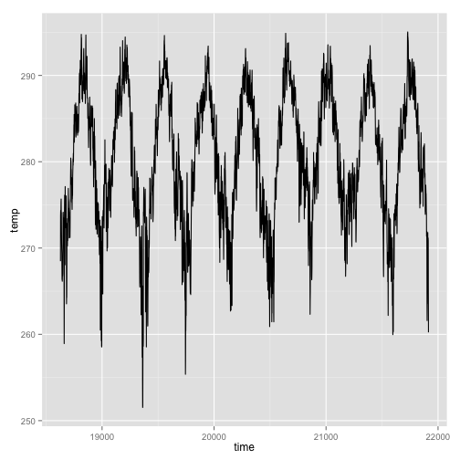

### GIS FILES

- Maps and associated data are often stored in **G**eographic **I**nformation **S**ystems (GIS)
- Most common form are shapefiles, an open-specification developed and regulated by [ESRI](http://www.esri.com)
- Describes vector features: points, lines, polygons to represent towns, rivers, states
- Come as a collection of three files: `.shp, .shx, .dbf`

### GIS FILES and R

- R packages: shapefiles, rgdal, maptools

```r
library(maptools)
xx <- readShapeSpatial(
  "../data/australia/region.shp")
object.size(as(xx, "SpatialPolygons"))
```

```
50302952 bytes
```

```r
xxx <- thinnedSpatialPoly(as(xx, "SpatialPolygons"),
  tolerance=0.5, minarea=0.001, topologyPreserve=TRUE)
object.size(as(xxx, "SpatialPolygons"))
```

```
15336848 bytes
```

### GIS FILES and R

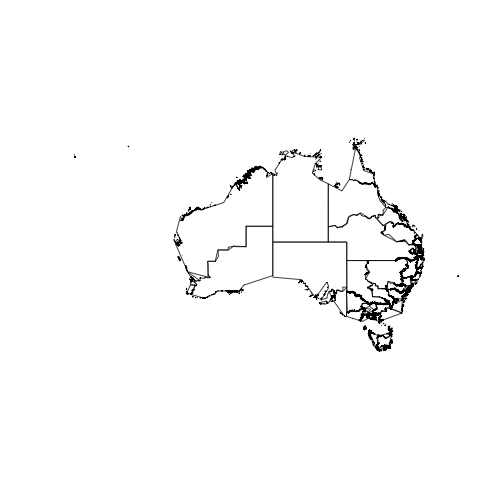

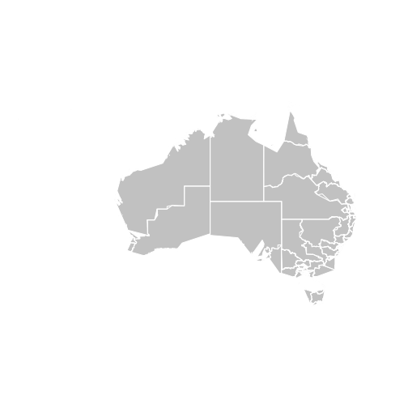

### SOUND FILES and R

- `tuneR` package enables reading wav and mp3 files
- Summary statistics, plots, spectral analysis

```r
library(tuneR)
i1 <- readWave("../data/ilikestatistics1.wav")
summary(i1)
```

```
Wave Object
    Number of Samples:      87552
    Duration (seconds):     1.99
    Samplingrate (Hertz):   44100
    Channels (Mono/Stereo): Stereo
    PCM (integer format):   TRUE
    Bit (8/16/24/32/64):    16

Summary statistics for channel(s):

        Min. 1st Qu. Median    Mean 3rd Qu.  Max.
left  -30200    -386     13 -0.0413     542 29200
right -30200    -387     13 -0.0538     542 29200
```

### SOUND FILES and R

```r
i1s <- periodogram(channel(i1, "left"))
summary(i1s)
```

```
Wspec Object

Number of Periodograms: 1
Estimated at 65536 Frequencies: 0.3365 ... NA

Further parameters:
df:      2
taper:   0
width:   131072
overlap: 0
normal.: TRUE

Properties of the Wave object:
Sampling rate: 44100
```

### SOUND FILES and R

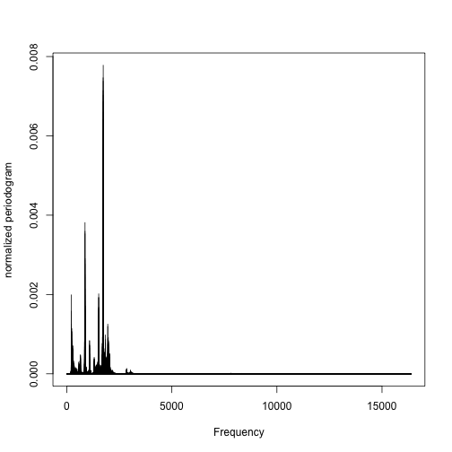

### IMAGES and R

The libraries `png, jpeg` can be used to process image into data.

[output not shown]

[figure not shown]

```r
library(png)
nasamap_png <- readPNG("../data/google-map.png")
dim(nasamap_png)
```

### HDF5

- Hierarchical Data Format (HDF)
- Binary format designed for massive, complex data
- Developed by [NCSA](http://www.ncsa.illinois.edu/) but now supported by non-profit [hdfgroup](http://www.hdfgroup.org/)

### HDF5 and R

```r
library(hdf5)
song <- hdf5load("../data/TRADDBK128F1483FF8.h5", load=FALSE, verbosity=0, tidy=TRUE)
song$metadata$songs$artist_name
```

```
[1] "R.E.M."
```

[Data source](http://labrosa.ee.columbia.edu/millionsong/pages/getting-dataset)

### SAM/BAM FILES

- Major text and binary formats for aligned DNA sequences - very large files!
- Used for studying gene expression

```r
# source("http://bioconductor.org/biocLite.R")
# biocLite("Rsamtools")
library(Rsamtools)
bamnormal <- scanBam("../data/normal.bam")[[1]]
names(bamnormal)
```

```
 [1] "qname"  "flag"   "rname"  "strand" "pos"    "qwidth" "mapq"   "cigar"
 [9] "mrnm"   "mpos"   "isize"  "seq"    "qual"
```

```r
length(bamnormal[["qname"]])
```

```
[1] 55147
```

```r
table(width(bamnormal[["seq"]]))
```

```
   21    22    24    25    27    28    32    36    37    38    41    43    44
    2     2     2     2     4     2     2     2     1     3     2     2     2
   51    52    53    75
    2     2     2 55113
```

### READING

[Rearranging, summarizing data: http://www.jstatsoft.org/v40/i01/](http://www.jstatsoft.org/v40/i01/)

- What is the split-apply-combine strategy?
- Why would you split data?
- Where would this be useful?

Make a blog entry by 3pm Wednesday, Jan 22.